# Project 2

Camryn Burley, Anna Haikl, and Joseph Keogh

12-4-19

Abstract

On our honor as students, we have neither given nor received aid on this assignment.

# Load Data and Impute Missing Values

```r
setwd(datadir)

airquality = read.csv('AirQualityUCI.csv')

# replace -200 with NA
airquality[airquality == -200] <- NA

# convert integer type to numeric
intcols = c(4,5,7,8,9,10,11,12)
for(i in 1:length(intcols)){
  airquality[,intcols[i]] <- as.numeric(airquality[,intcols[i]])
}

setwd(sourcedir)

# create new data frame with just CO and NO2
AQdata = airquality[,c(3,10)]

# impute missing air quality data
f <- ~ CO.GT. + NO2.GT.
t <- c(seq(1,dim(AQdata)[1],1))
i <- mnimput(f, AQdata, eps=1e-3, ts=TRUE, method='gam',
             ga.control=list(formula=paste(names(AQdata)[c(1:3)],'~ns(t,2)')))

# set airquality to imputed data
AQdata <- i$filled.dataset

# aggregate to daily maxima for model building
dailyAQ <- aggregate(AQdata, by=list(as.Date(airquality[,1],"%m/%d/%Y")), FUN=max)
```

# Create Testing and Training Data

```r
# the index to split the data on
separationIndex <- nrow(dailyAQ)-6

# split the data
air.train <- dailyAQ[1:separationIndex-1,]
air.test <- dailyAQ[separationIndex:nrow(dailyAQ),]

# making sure no data was duplicated or lost
a <- nrow(dailyAQ)
b <- nrow(air.train)
c <- nrow(air.test)

# a
# b
# c
```

# Data Summary

```r
summary(air.train)
```

```
##     Group.1               CO.GT.          NO2.GT.
##  Min.   :2004-03-10   Min.   : 1.400   Min.   : 69.0
##  1st Qu.:2004-06-13   1st Qu.: 2.700   1st Qu.:124.6
##  Median :2004-09-17   Median : 4.132   Median :160.0
##  Mean   :2004-09-17   Mean   : 4.365   Mean   :164.5
##  3rd Qu.:2004-12-22   3rd Qu.: 5.600   3rd Qu.:196.2
##  Max.   :2005-03-28   Max.   :11.900   Max.   :340.0
```

The data is from March 2004 through April 2005. We are modeling the ambient daily maximum carbon monoxide (CO) and nitrogen dioxide (NO2) concentrations.

# Univariate Time Series for CO

## Visualize the Data

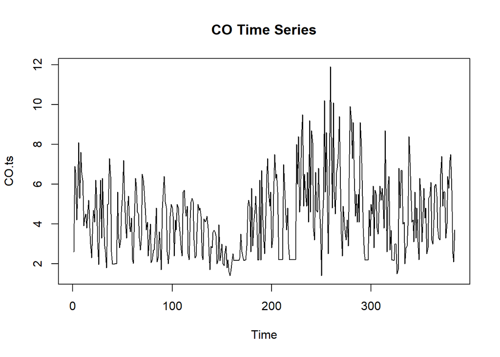

```r
# create time series
CO.ts <- ts(air.train$CO.GT.)

# visualize raw data
plot(CO.ts, main = "CO Time Series")
```

There appears to be some trend from looking at the plot of the time series (i.e. the mean is not constant for the whole time series). There may be some seasonality, but we are unsure as of now if this fluctuation is from seasonality or if it is random.

```r
# periodogram
pg.CO <- spec.pgram(CO.ts,spans=9,demean=T,log='no')
```

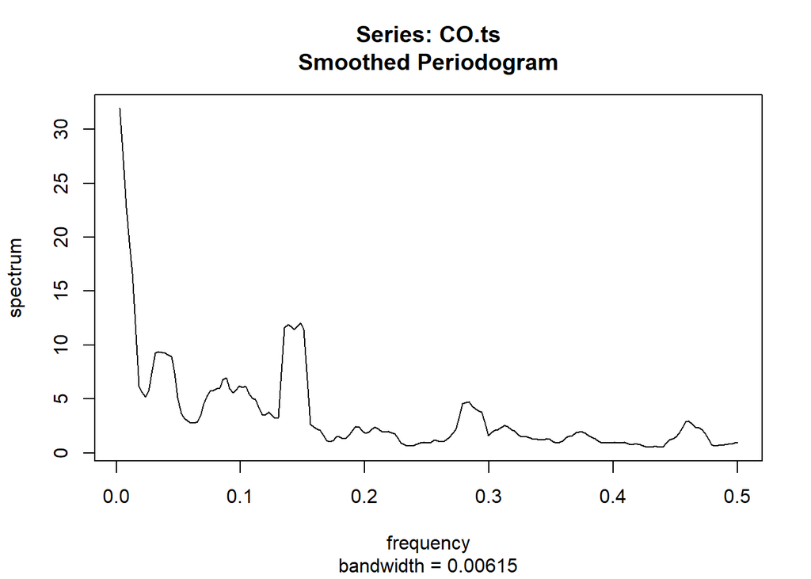

Based on the periodogram, there are multiple possibilities for the period of a seasonal component. There are a few spikes, each of which indicate a possible frequency/period to explain the seasonality of the data. We predict that if seasonality is significant in the model, it will be based on a complex wave. This is because there are many options for the period of potential seasons.

## Seasonality

### Finding Potential Periods

```r
# sort the frequencies based on influence
sorted.spec <- sort(pg.CO$spec, decreasing=T, index.return=T)

# convert to periods
sorted.omegas <- pg.CO$freq[sorted.spec$ix]
sorted.Ts <- 1/pg.CO$freq[sorted.spec$ix]

# the cutoff for influential
CO.pg.cutoff <- 5

# the top periods
print('top periods')
```

```
## [1] "top periods"
```

```r
sorted.Ts[1:CO.pg.cutoff]
```

```
## [1] 384.0 192.0 128.0  96.0  76.8
```

```r
# top frequencies
## to double check that this makes sense based on periodogram
print('top frequencies')
```

```
## [1] "top frequencies"
```

```r
sorted.omegas[1:CO.pg.cutoff]
```

```
## [1] 0.002604167 0.005208333 0.007812500 0.010416667 0.013020833
```

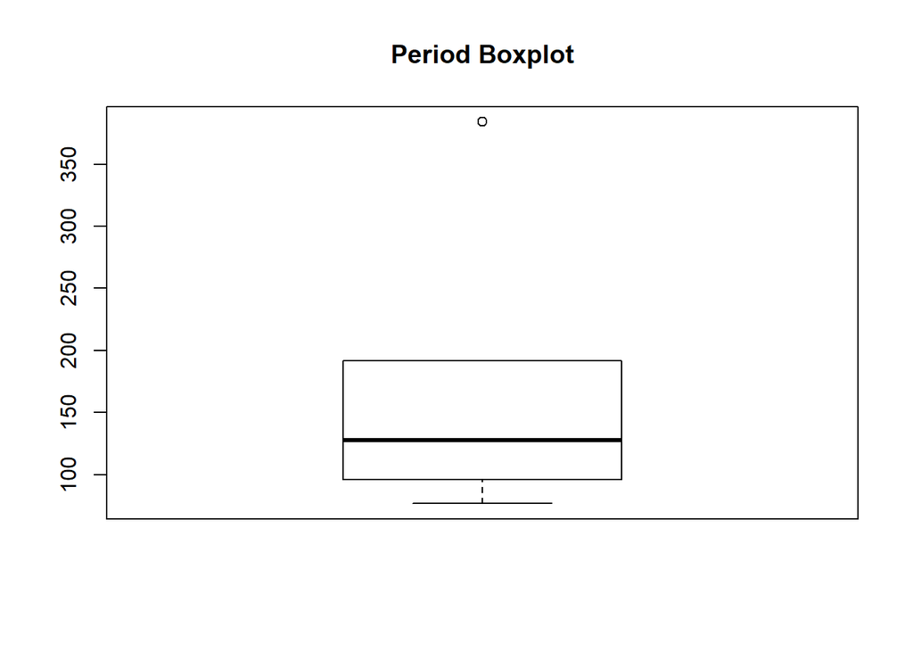

```r
# visual
CO.pg.box <- boxplot(sorted.Ts[1:CO.pg.cutoff], main="Period Boxplot")
```

```r
# the average influential period
print('mean of top periods')
```

```
## [1] "mean of top periods"
```

```r
CO.pg.box.mean <- CO.pg.box$stats[3]
print(CO.pg.box.mean)
```

```
## [1] 128
```

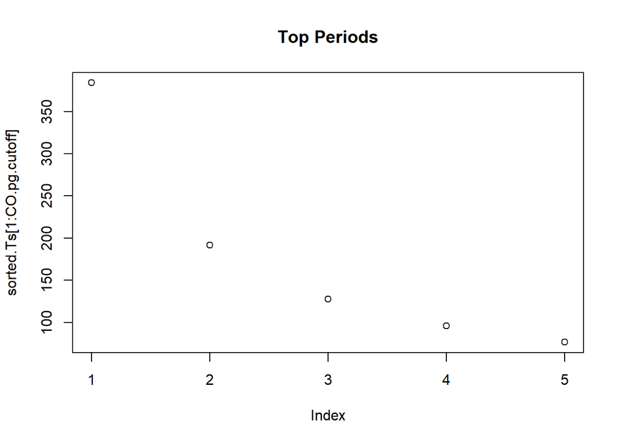

```r
# plot top periods
plot(sorted.Ts[1:CO.pg.cutoff], main = "Top Periods")
```

We found the frequencies of the largest spikes in the periodogram graph and converted them to periods by taking 1/the frequency. The five largest spikes correspond to periods of 384, 192, 128, 96, and 76.8 days. We considered these our “top” choices for periods to explain seasonality.  
We are concerned that the reason we are seeing a period of 384 days is because this is close to the length of the data set and not because there is actual correlation between data values collected 384 days apart. We will investigate whether or not to use this period in the following sections.

### Create Model with Potential Periods

To begin, we made a model without the 384 day period but that included the other four periods.

```r
# assign potential periods to variables
CO.p1 <- sorted.Ts[1]
CO.p2 <- sorted.Ts[2]
CO.p3 <- sorted.Ts[3]
CO.p4 <- sorted.Ts[4]
CO.p5 <- sorted.Ts[5]

# CO.p1
# CO.p2
# CO.p3
# CO.p4
# CO.p5

# create time variable
time.CO<-c(1:length(CO.ts))

# model
CO.lm.top4 <- lm(CO.ts ~ sin(2*pi*time.CO/CO.p2) +
                         cos(2*pi*time.CO/CO.p2) +
                         sin(2*pi*time.CO/CO.p3) +
                         cos(2*pi*time.CO/CO.p3) +
                         sin(2*pi*time.CO/CO.p4) +
                         cos(2*pi*time.CO/CO.p4)+
                         sin(2*pi*time.CO/CO.p5) +
                         cos(2*pi*time.CO/CO.p5))

# model summary
summary(CO.lm.top4)
```

```
##
## Call:
## lm(formula = CO.ts ~ sin(2 * pi * time.CO/CO.p2) + cos(2 * pi *
##     time.CO/CO.p2) + sin(2 * pi * time.CO/CO.p3) + cos(2 * pi *
##     time.CO/CO.p3) + sin(2 * pi * time.CO/CO.p4) + cos(2 * pi *
##     time.CO/CO.p4) + sin(2 * pi * time.CO/CO.p5) + cos(2 * pi *
##     time.CO/CO.p5))
##
## Residuals:
##     Min      1Q  Median      3Q     Max
## -3.9162 -1.3323 -0.2028  1.1502  6.4368
##
## Coefficients:
##                             Estimate Std. Error t value Pr(>|t|)
## (Intercept)                  4.36457    0.09288  46.994  < 2e-16 ***
## sin(2 * pi * time.CO/CO.p2)  0.61552    0.13135   4.686  3.9e-06 ***
## cos(2 * pi * time.CO/CO.p2) -0.14310    0.13135  -1.089 0.276645
## sin(2 * pi * time.CO/CO.p3) -0.23858    0.13135  -1.816 0.070099 .
## cos(2 * pi * time.CO/CO.p3)  0.43888    0.13135   3.341 0.000917 ***
## sin(2 * pi * time.CO/CO.p4) -0.05762    0.13135  -0.439 0.661117
## cos(2 * pi * time.CO/CO.p4)  0.23999    0.13135   1.827 0.068470 .
## sin(2 * pi * time.CO/CO.p5) -0.01826    0.13135  -0.139 0.889533
## cos(2 * pi * time.CO/CO.p5) -0.21791    0.13135  -1.659 0.097949 .
## ---
## Signif. codes:  0 '***' 0.001 '**' 0.01 '*' 0.05 '.' 0.1 ' ' 1
##
## Residual standard error: 1.82 on 375 degrees of freedom
## Multiple R-squared:  0.1048, Adjusted R-squared:  0.08573
## F-statistic: 5.489 on 8 and 375 DF,  p-value: 1.441e-06
```

Based on the model utility test, this model is significant at the 0.05 level, so we will continue to analyze its performance in comparison to other models. We will compare it to a model that only uses the first “important” period (i.e. the period associated with the largest spike in the periodogram, with the exception of the one corresponding to 384 days).

### Compare Larger Model with Model with Only First Important Period

```r
# actual model
CO.lm.top1 <- lm(CO.ts ~ sin(2*pi*time.CO/CO.p2) + cos(2*pi*time.CO/CO.p2))

# model summary
summary(CO.lm.top1)
```

```
##
## Call:
## lm(formula = CO.ts ~ sin(2 * pi * time.CO/CO.p2) + cos(2 * pi *
##     time.CO/CO.p2))
##
## Residuals:
##     Min      1Q  Median      3Q     Max
## -3.5934 -1.5526 -0.1842  1.2392  6.9518
##
## Coefficients:
##                             Estimate Std. Error t value Pr(>|t|)
## (Intercept)                  4.36457    0.09466  46.109  < 2e-16 ***
## sin(2 * pi * time.CO/CO.p2)  0.61552    0.13387   4.598 5.81e-06 ***
## cos(2 * pi * time.CO/CO.p2) -0.14310    0.13387  -1.069    0.286
## ---
## Signif. codes:  0 '***' 0.001 '**' 0.01 '*' 0.05 '.' 0.1 ' ' 1
##
## Residual standard error: 1.855 on 381 degrees of freedom
## Multiple R-squared:  0.05526,    Adjusted R-squared:  0.0503
## F-statistic: 11.14 on 2 and 381 DF,  p-value: 1.983e-05
```

```r
# anova
anova(CO.lm.top1, CO.lm.top4)
```

```
## Analysis of Variance Table
##
## Model 1: CO.ts ~ sin(2 * pi * time.CO/CO.p2) + cos(2 * pi * time.CO/CO.p2)
## Model 2: CO.ts ~ sin(2 * pi * time.CO/CO.p2) + cos(2 * pi * time.CO/CO.p2) +
##     sin(2 * pi * time.CO/CO.p3) + cos(2 * pi * time.CO/CO.p3) +
##     sin(2 * pi * time.CO/CO.p4) + cos(2 * pi * time.CO/CO.p4) +
##     sin(2 * pi * time.CO/CO.p5) + cos(2 * pi * time.CO/CO.p5)
##   Res.Df    RSS Df Sum of Sq      F   Pr(>F)
## 1    381 1310.9
## 2    375 1242.1  6    68.788 3.4612 0.002429 **
## ---
## Signif. codes:  0 '***' 0.001 '**' 0.01 '*' 0.05 '.' 0.1 ' ' 1
```

The p-value of the partial F test is 0.0024, which is significant at the 0.05 level. We reject the null hypothesis, which means that the larger model contains at least one coefficient, not shared with the smaller model, that is significant. As a result of this test, we have concluded that the larger model is better at explaining variability.

### Create Model with All Identified Periods

```r
# actual model
CO.lm.top5 <- lm(CO.ts ~ sin(2*pi*time.CO/CO.p1) +
                         cos(2*pi*time.CO/CO.p1) +
                         sin(2*pi*time.CO/CO.p2) +
                         cos(2*pi*time.CO/CO.p2) +
                         sin(2*pi*time.CO/CO.p3) +
                         cos(2*pi*time.CO/CO.p3) +
                         sin(2*pi*time.CO/CO.p4) +
                         cos(2*pi*time.CO/CO.p4)+
                         sin(2*pi*time.CO/CO.p5) +
                         cos(2*pi*time.CO/CO.p5))

# model summary
summary(CO.lm.top5)
```

```
##
## Call:
## lm(formula = CO.ts ~ sin(2 * pi * time.CO/CO.p1) + cos(2 * pi *
##     time.CO/CO.p1) + sin(2 * pi * time.CO/CO.p2) + cos(2 * pi *
##     time.CO/CO.p2) + sin(2 * pi * time.CO/CO.p3) + cos(2 * pi *
##     time.CO/CO.p3) + sin(2 * pi * time.CO/CO.p4) + cos(2 * pi *
##     time.CO/CO.p4) + sin(2 * pi * time.CO/CO.p5) + cos(2 * pi *
##     time.CO/CO.p5))
##
## Residuals:
##    Min     1Q Median     3Q    Max
## -4.482 -1.302 -0.115  1.082  5.783
##
## Coefficients:
##                             Estimate Std. Error t value Pr(>|t|)
## (Intercept)                  4.36457    0.08767  49.785  < 2e-16 ***
## sin(2 * pi * time.CO/CO.p1) -0.83539    0.12398  -6.738 6.11e-11 ***
## cos(2 * pi * time.CO/CO.p1)  0.19483    0.12398   1.571 0.116926
## sin(2 * pi * time.CO/CO.p2)  0.61552    0.12398   4.965 1.05e-06 ***
## cos(2 * pi * time.CO/CO.p2) -0.14310    0.12398  -1.154 0.249164
## sin(2 * pi * time.CO/CO.p3) -0.23858    0.12398  -1.924 0.055072 .
## cos(2 * pi * time.CO/CO.p3)  0.43888    0.12398   3.540 0.000451 ***
## sin(2 * pi * time.CO/CO.p4) -0.05762    0.12398  -0.465 0.642361
## cos(2 * pi * time.CO/CO.p4)  0.23999    0.12398   1.936 0.053661 .
## sin(2 * pi * time.CO/CO.p5) -0.01826    0.12398  -0.147 0.883018
## cos(2 * pi * time.CO/CO.p5) -0.21791    0.12398  -1.758 0.079644 .
## ---
## Signif. codes:  0 '***' 0.001 '**' 0.01 '*' 0.05 '.' 0.1 ' ' 1
##
## Residual standard error: 1.718 on 373 degrees of freedom
## Multiple R-squared:  0.2066, Adjusted R-squared:  0.1854
## F-statistic: 9.716 on 10 and 373 DF,  p-value: 1.876e-14
```

```r
# compare with smaller model
anova(CO.lm.top4, CO.lm.top5)
```

```
## Analysis of Variance Table
##
## Model 1: CO.ts ~ sin(2 * pi * time.CO/CO.p2) + cos(2 * pi * time.CO/CO.p2) +
##     sin(2 * pi * time.CO/CO.p3) + cos(2 * pi * time.CO/CO.p3) +
##     sin(2 * pi * time.CO/CO.p4) + cos(2 * pi * time.CO/CO.p4) +
##     sin(2 * pi * time.CO/CO.p5) + cos(2 * pi * time.CO/CO.p5)
## Model 2: CO.ts ~ sin(2 * pi * time.CO/CO.p1) + cos(2 * pi * time.CO/CO.p1) +
##     sin(2 * pi * time.CO/CO.p2) + cos(2 * pi * time.CO/CO.p2) +
##     sin(2 * pi * time.CO/CO.p3) + cos(2 * pi * time.CO/CO.p3) +
##     sin(2 * pi * time.CO/CO.p4) + cos(2 * pi * time.CO/CO.p4) +
##     sin(2 * pi * time.CO/CO.p5) + cos(2 * pi * time.CO/CO.p5)
##   Res.Df    RSS Df Sum of Sq      F   Pr(>F)
## 1    375 1242.1
## 2    373 1100.8  2    141.28 23.935 1.66e-10 ***
## ---
## Signif. codes:  0 '***' 0.001 '**' 0.01 '*' 0.05 '.' 0.1 ' ' 1
```

We created a model that used all five periods identified from the periodogram. We compared it to the model without the 384-day period using a partial F test. The test is significant at the 0.05 level, which means there is significant evidence to use the larger model. We will use the model with all five periods to explain seasonality in further analysis.

### Visual Inspection of Model

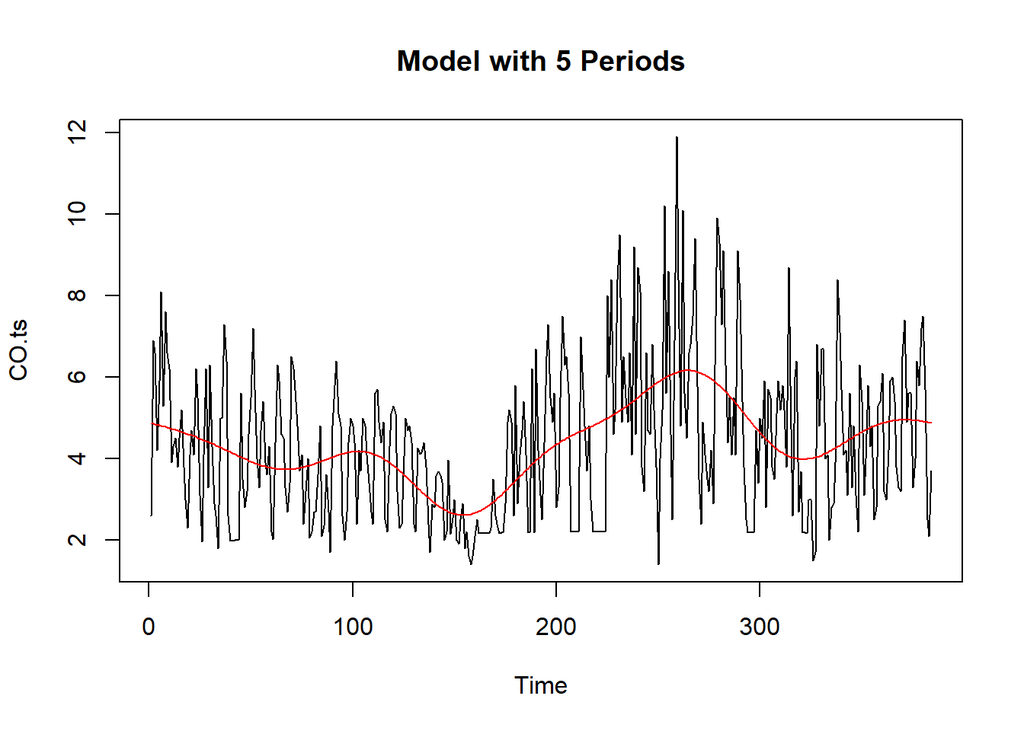

```r
plot(CO.ts, main = "Model with 5 Periods")
lines(CO.lm.top5$fitted.values, col = "red")
```

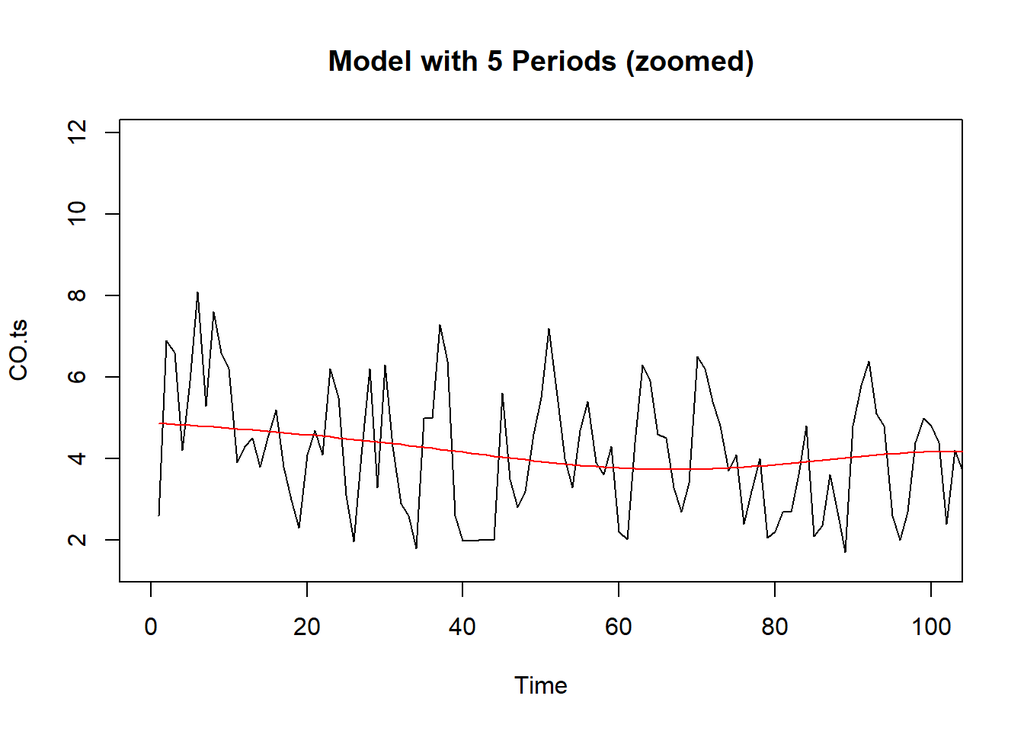

```r
plot(CO.ts, xlim=c(0,100), main = "Model with 5 Periods (zoomed)")
lines(CO.lm.top5$fitted.values, col = "red")
```

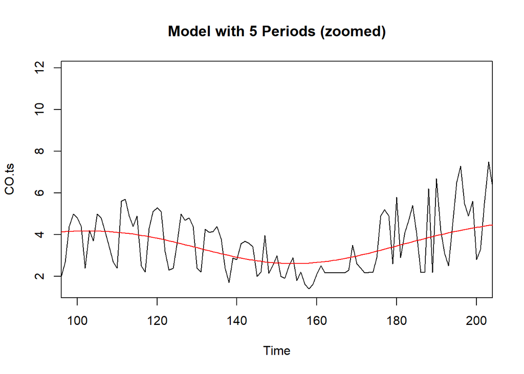

```r
plot(CO.ts, xlim=c(100,200), main = "Model with 5 Periods (zoomed)")
lines(CO.lm.top5$fitted.values, col = "red")
```

We plotted the fitted values of the model in red over the graph of the time series data. We plotted the entire time series and also zoomed in to see t = [0, 100] and t = [100, 200]. The model follows the general trend of the data, but there are no small fluctuations, of which the data has many. We may need to add a term with a smaller period in order to capture these smaller fluctuations.

### Explore Adding Higher Frequency Components

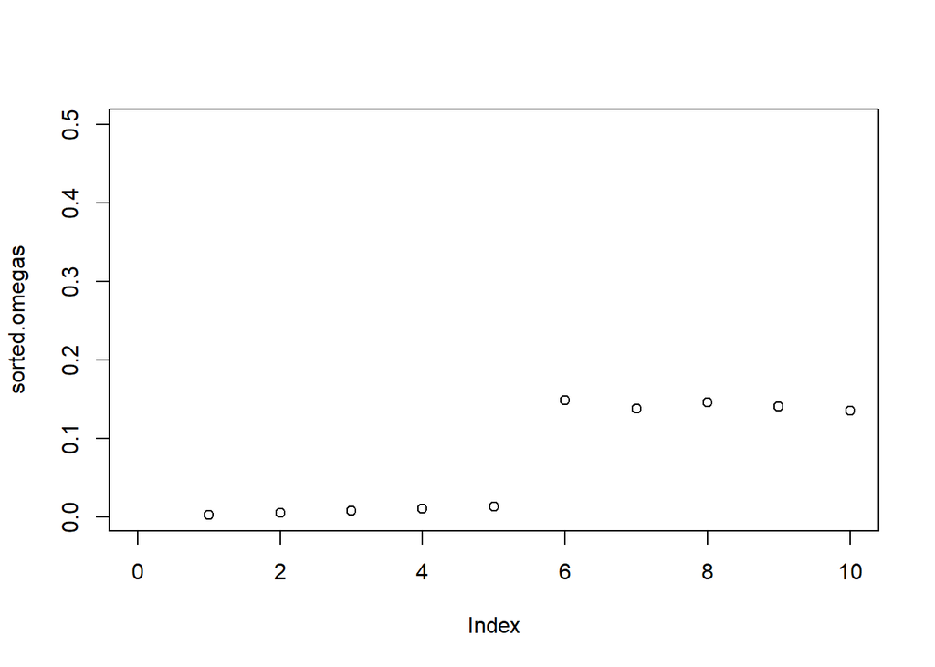

```r
# visual for frequency
plot(sorted.omegas, xlim=c(0,10))
```

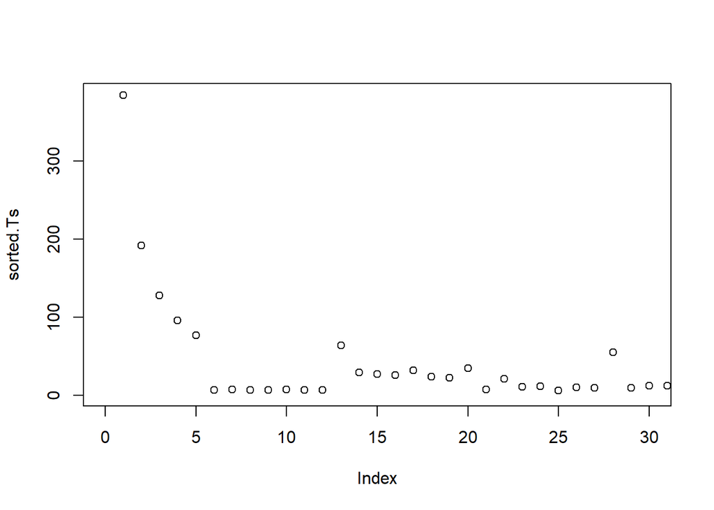

```r
# visual for periods
plot(sorted.Ts, xlim=c(0,30))
```

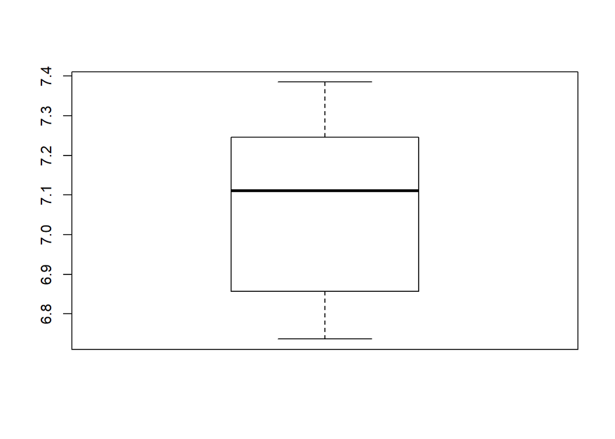

```r
# look at the 6th through 10th most influencial periods
next.low.period <- boxplot(sorted.Ts[6:10])$stats[3]
```

```r
next.low.period
```

```
## [1] 7.111111
```

The average of the periods associated with the next five highest spikes of the periodogram is about 7 days (7.11). A period of around 7 days makes sense to us, as CO production could vary weekly from people working and commuting.

### Add New Period to Model

We made a new model with all five periods in our previous model with the addition of the new period of around 7 days.

```r
CO.p6 <- next.low.period

# model
CO.lm.top6 <- lm(CO.ts ~ sin(2*pi*time.CO/CO.p1) +
                         cos(2*pi*time.CO/CO.p1) +
                         sin(2*pi*time.CO/CO.p2) +
                         cos(2*pi*time.CO/CO.p2) +
                         sin(2*pi*time.CO/CO.p3) +
                         cos(2*pi*time.CO/CO.p3) +
                         sin(2*pi*time.CO/CO.p4) +
                         cos(2*pi*time.CO/CO.p4) +
                         sin(2*pi*time.CO/CO.p5) +
                         cos(2*pi*time.CO/CO.p5) +
                         sin(2*pi*time.CO/CO.p6) +
                         cos(2*pi*time.CO/CO.p6))

# model summary
summary(CO.lm.top6)
```

```
##
## Call:
## lm(formula = CO.ts ~ sin(2 * pi * time.CO/CO.p1) + cos(2 * pi *
##     time.CO/CO.p1) + sin(2 * pi * time.CO/CO.p2) + cos(2 * pi *
##     time.CO/CO.p2) + sin(2 * pi * time.CO/CO.p3) + cos(2 * pi *
##     time.CO/CO.p3) + sin(2 * pi * time.CO/CO.p4) + cos(2 * pi *
##     time.CO/CO.p4) + sin(2 * pi * time.CO/CO.p5) + cos(2 * pi *
##     time.CO/CO.p5) + sin(2 * pi * time.CO/CO.p6) + cos(2 * pi *
##     time.CO/CO.p6))
##
## Residuals:
##     Min      1Q  Median      3Q     Max
## -4.2939 -1.2539 -0.1561  1.0615  5.8593
##
## Coefficients:
##                             Estimate Std. Error t value Pr(>|t|)
## (Intercept)                  4.36457    0.08756  49.845  < 2e-16 ***
## sin(2 * pi * time.CO/CO.p1) -0.83539    0.12383  -6.746 5.85e-11 ***
## cos(2 * pi * time.CO/CO.p1)  0.19483    0.12383   1.573 0.116493
## sin(2 * pi * time.CO/CO.p2)  0.61552    0.12383   4.971 1.02e-06 ***
## cos(2 * pi * time.CO/CO.p2) -0.14310    0.12383  -1.156 0.248602
## sin(2 * pi * time.CO/CO.p3) -0.23858    0.12383  -1.927 0.054786 .
## cos(2 * pi * time.CO/CO.p3)  0.43888    0.12383   3.544 0.000444 ***
## sin(2 * pi * time.CO/CO.p4) -0.05762    0.12383  -0.465 0.641963
## cos(2 * pi * time.CO/CO.p4)  0.23999    0.12383   1.938 0.053380 .
## sin(2 * pi * time.CO/CO.p5) -0.01826    0.12383  -0.147 0.882879
## cos(2 * pi * time.CO/CO.p5) -0.21791    0.12383  -1.760 0.079289 .
## sin(2 * pi * time.CO/CO.p6) -0.20923    0.12383  -1.690 0.091946 .
## cos(2 * pi * time.CO/CO.p6) -0.02502    0.12383  -0.202 0.839997
## ---
## Signif. codes:  0 '***' 0.001 '**' 0.01 '*' 0.05 '.' 0.1 ' ' 1
##
## Residual standard error: 1.716 on 371 degrees of freedom
## Multiple R-squared:  0.2128, Adjusted R-squared:  0.1873
## F-statistic: 8.357 on 12 and 371 DF,  p-value: 5.083e-14
```

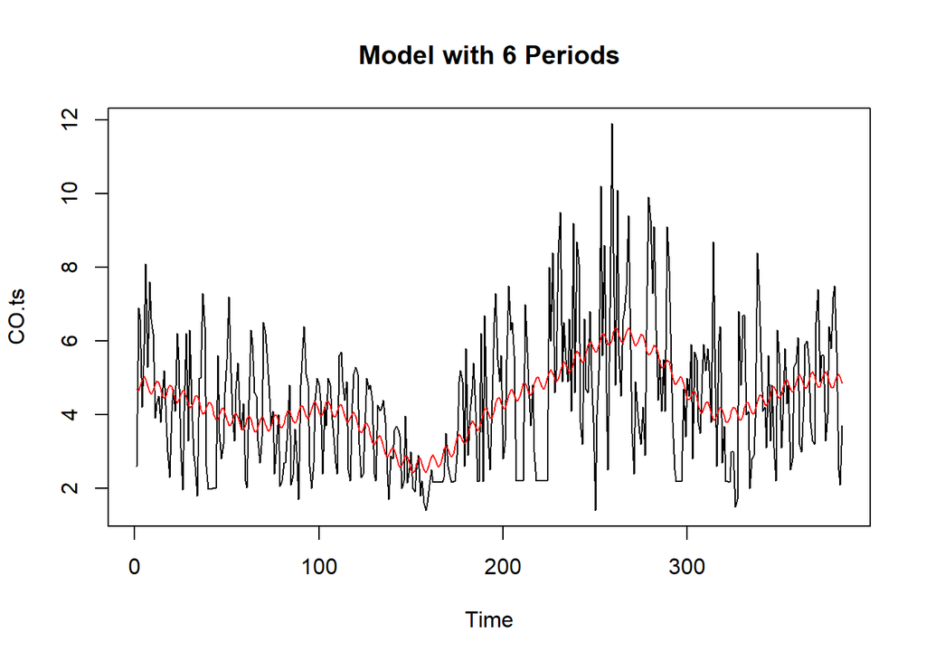

```r
# visual inspection
plot(CO.ts, main = "Model with 6 Periods")
lines(CO.lm.top6$fitted.values, col = "red")
```

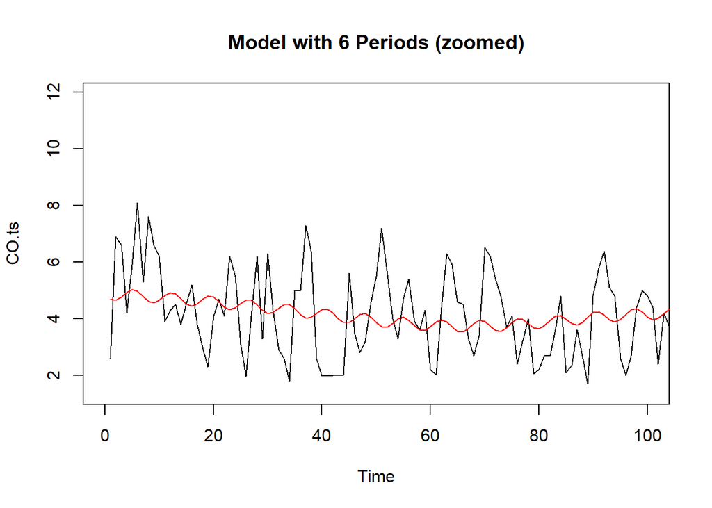

```r
plot(CO.ts, xlim=c(0,100), main = "Model with 6 Periods (zoomed)")
lines(CO.lm.top6$fitted.values, col = "red")
```

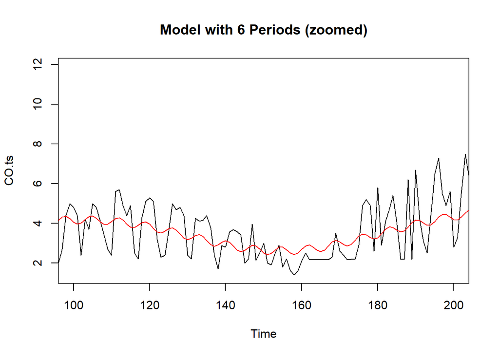

```r
plot(CO.ts, xlim=c(100,200), main = "Model with 6 Periods (zoomed)")
lines(CO.lm.top6$fitted.values, col = "red")
```

Upon visually inspecting this new model, we see smaller fluctuations, which we wanted. However, we do see that the peaks of the smaller waves do not consistently match up with where the data has a peak, based on the zoomed in graphs.  
After determining if there is a significant trend, we will compare the potential trend and seasonality models with five and six periods to determine which one will be the best selection for our final linear model.

## Trend

### Model Time Series Based on Time

```r
# model
CO.lm.trend <- lm(CO.ts ~ time.CO)

# summary analysis
summary(CO.lm.trend)
```

```
##
## Call:
## lm(formula = CO.ts ~ time.CO)
##
## Residuals:
##     Min      1Q  Median      3Q     Max
## -3.2485 -1.6980 -0.0525  1.0863  7.3442
##
## Coefficients:
##             Estimate Std. Error t value Pr(>|t|)
## (Intercept) 3.810929   0.192140  19.834  < 2e-16 ***
## time.CO     0.002876   0.000865   3.325  0.00097 ***
## ---
## Signif. codes:  0 '***' 0.001 '**' 0.01 '*' 0.05 '.' 0.1 ' ' 1
##
## Residual standard error: 1.879 on 382 degrees of freedom
## Multiple R-squared:  0.02813,    Adjusted R-squared:  0.02558
## F-statistic: 11.06 on 1 and 382 DF,  p-value: 0.0009695
```

The p-value is 0.00097, so there is a significant trend in the data.

### Visualize Trend

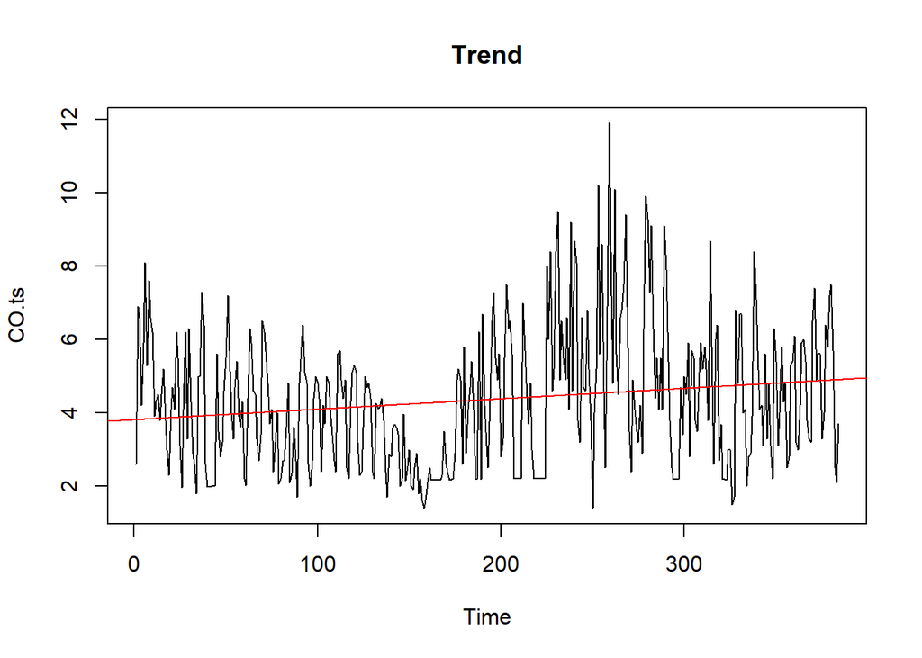

```r
plot(CO.ts, main = "Trend")
abline(CO.lm.trend, col='red')
```

This graph shows the trendline plotted in red over the time series.

### Model Comparison: Trend and Seasonality Together

```r
# model with trend and 5 periods
CO.seasonal5.trend <- lm(CO.ts ~ time.CO + sin(2*pi*time.CO/CO.p1) +
                         cos(2*pi*time.CO/CO.p1) +
                         sin(2*pi*time.CO/CO.p2) +
                         cos(2*pi*time.CO/CO.p2) +
                         sin(2*pi*time.CO/CO.p3) +
                         cos(2*pi*time.CO/CO.p3) +
                         sin(2*pi*time.CO/CO.p4) +
                         cos(2*pi*time.CO/CO.p4)+
                         sin(2*pi*time.CO/CO.p5) +
                         cos(2*pi*time.CO/CO.p5))

# model with trend and 6 periods
CO.seasonal6.trend <- lm(CO.ts ~ time.CO + sin(2*pi*time.CO/CO.p1) +
                         cos(2*pi*time.CO/CO.p1) +
                         sin(2*pi*time.CO/CO.p2) +
                         cos(2*pi*time.CO/CO.p2) +
                         sin(2*pi*time.CO/CO.p3) +
                         cos(2*pi*time.CO/CO.p3) +
                         sin(2*pi*time.CO/CO.p4) +
                         cos(2*pi*time.CO/CO.p4) +
                         sin(2*pi*time.CO/CO.p5) +
                         cos(2*pi*time.CO/CO.p5) +
                         sin(2*pi*time.CO/CO.p6) +
                         cos(2*pi*time.CO/CO.p6))

anova(CO.seasonal5.trend, CO.seasonal6.trend)
```

```
## Analysis of Variance Table
##
## Model 1: CO.ts ~ time.CO + sin(2 * pi * time.CO/CO.p1) + cos(2 * pi *
##     time.CO/CO.p1) + sin(2 * pi * time.CO/CO.p2) + cos(2 * pi *
##     time.CO/CO.p2) + sin(2 * pi * time.CO/CO.p3) + cos(2 * pi *
##     time.CO/CO.p3) + sin(2 * pi * time.CO/CO.p4) + cos(2 * pi *
##     time.CO/CO.p4) + sin(2 * pi * time.CO/CO.p5) + cos(2 * pi *
##     time.CO/CO.p5)
## Model 2: CO.ts ~ time.CO + sin(2 * pi * time.CO/CO.p1) + cos(2 * pi *
##     time.CO/CO.p1) + sin(2 * pi * time.CO/CO.p2) + cos(2 * pi *
##     time.CO/CO.p2) + sin(2 * pi * time.CO/CO.p3) + cos(2 * pi *
##     time.CO/CO.p3) + sin(2 * pi * time.CO/CO.p4) + cos(2 * pi *
##     time.CO/CO.p4) + sin(2 * pi * time.CO/CO.p5) + cos(2 * pi *
##     time.CO/CO.p5) + sin(2 * pi * time.CO/CO.p6) + cos(2 * pi *
##     time.CO/CO.p6)
##   Res.Df    RSS Df Sum of Sq      F Pr(>F)
## 1    372 1098.1
## 2    370 1089.2  2     8.914 1.5141 0.2214
```

The p-value of the partial F test is large (not significant at the 0.05 level), which means that the smaller model is preferred. Based on this test, we would choose the model with trend and five periods.

#### Visual Comparison

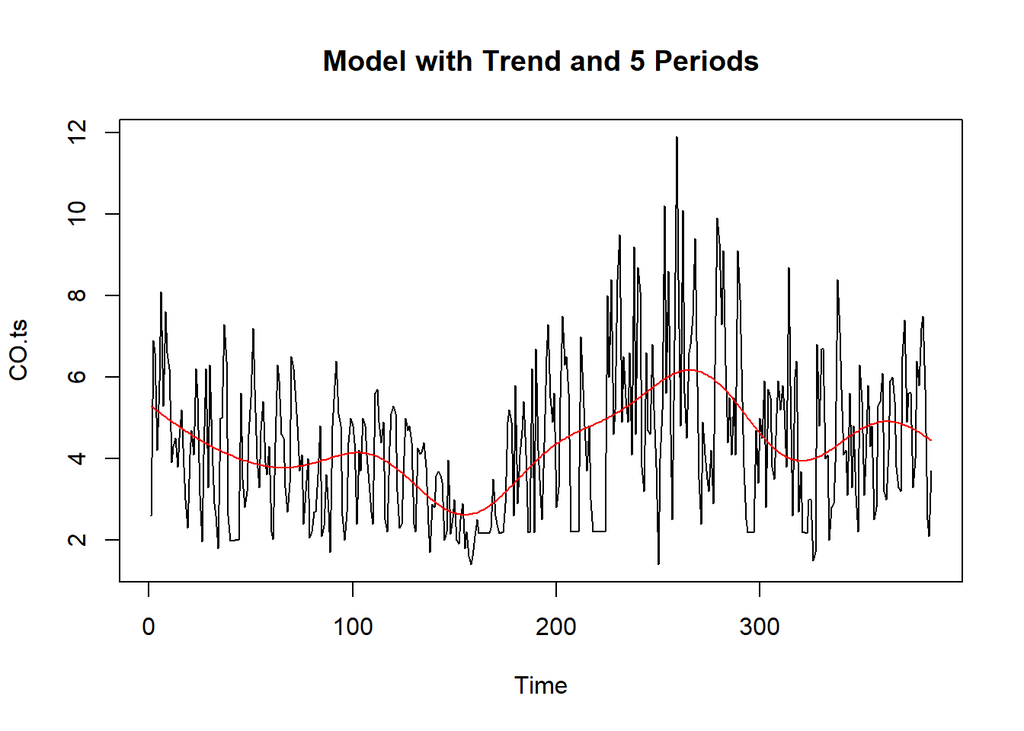

```r
model1 <- CO.seasonal5.trend
plot(CO.ts, main = "Model with Trend and 5 Periods")
lines(model1$fitted.values, col = "red")
```

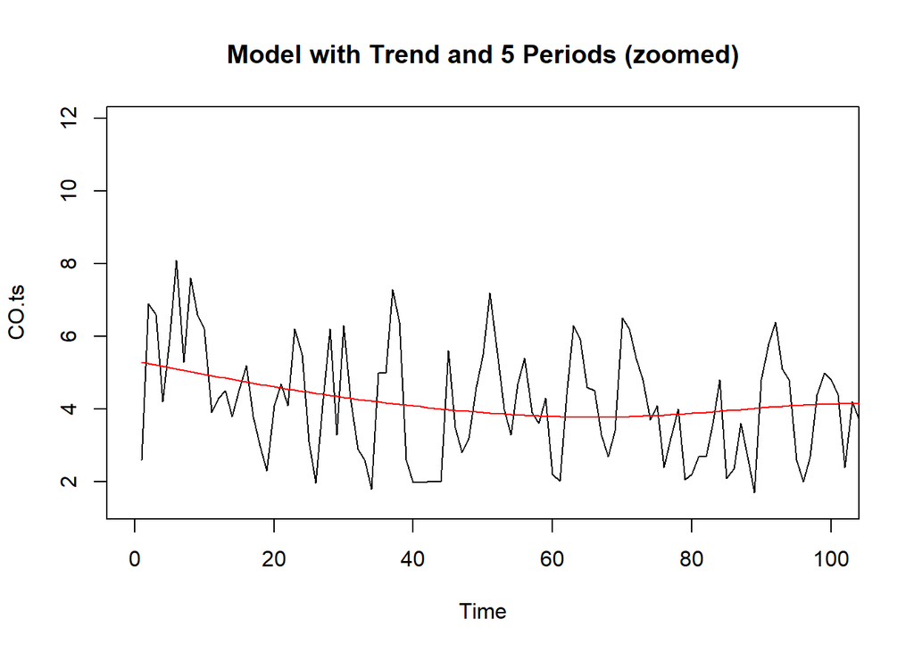

```r
plot(CO.ts, xlim=c(0,100), main = "Model with Trend and 5 Periods (zoomed)")
lines(model1$fitted.values, col = "red")
```

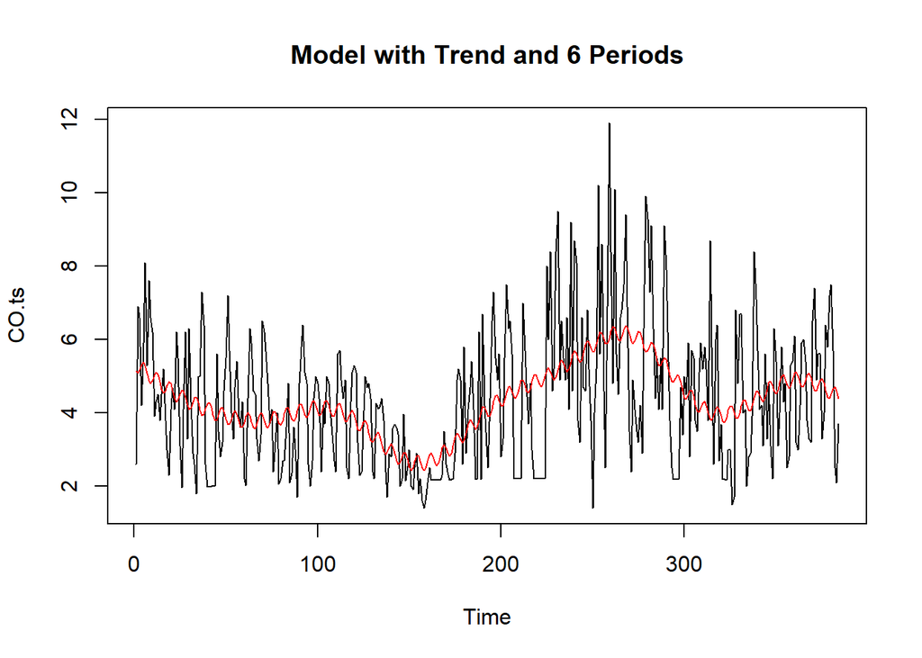

```r
model2 <- CO.seasonal6.trend
plot(CO.ts, main = "Model with Trend and 6 Periods")
lines(model2$fitted.values, col = "red")
```

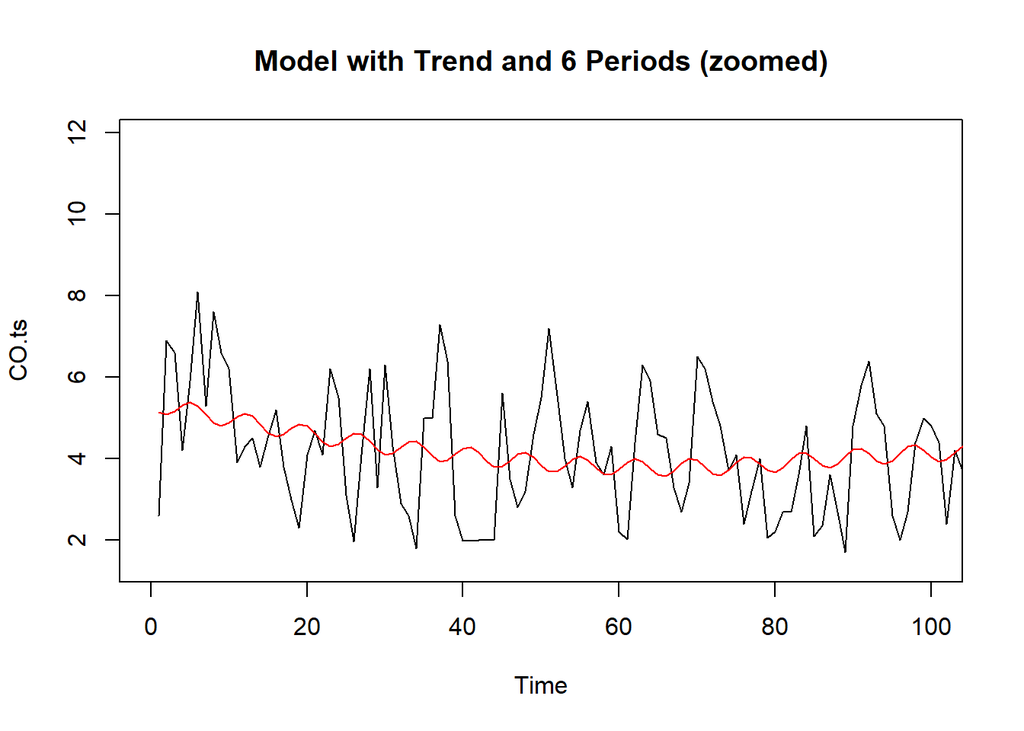

```r
plot(CO.ts, xlim=c(0,100), main = "Model with Trend and 6 Periods (zoomed)")
lines(model2$fitted.values, col = "red")
```

Based on visual inspection, both models capture the overall trend of the data well. The model with trend and six periods has smaller fluctuations, instead of being a smooth curve like the other model, which visually appears to look more similar to the time series. Again, we see that the peaks of the model do not always occur at the same time value as the peaks of the data.

#### Comparison Using Metrics

```r
# Adjusted R^2: model with trend and 5 periods
summary(CO.seasonal5.trend)$adj.r.squared
```

```
## [1] 0.1852438
```

```r
# AIC: model with trend and 5 periods
AIC(CO.seasonal5.trend)
```

```
## [1] 1519.205
```

```r
# Adjusted R^2: model with trend and 6 periods
summary(CO.seasonal6.trend)$adj.r.squared
```

```
## [1] 0.1874895
```

```r
# AIC: model with trend and 6 periods
AIC(CO.seasonal6.trend)
```

```
## [1] 1520.075
```

The adjusted R^2 of the model that includes the trend and 5 periods is 0.185. The adjusted R^2 of the model that includes the trend and 6 periods is 0.187. Based on adjusted R^2, we would select the model with 6 periods, though they are very close based on this metric and neither value is particularly close to 1.  
The AIC of the model with 5 periods is 1519.205. The AIC of the model with 6 periods is 1520.075. Based on AIC, we would choose the model with 5 periods, because it has the smaller AIC value. Again, the values are very similar, though.

#### Diagnostics

**Residuals vs. Fitted**

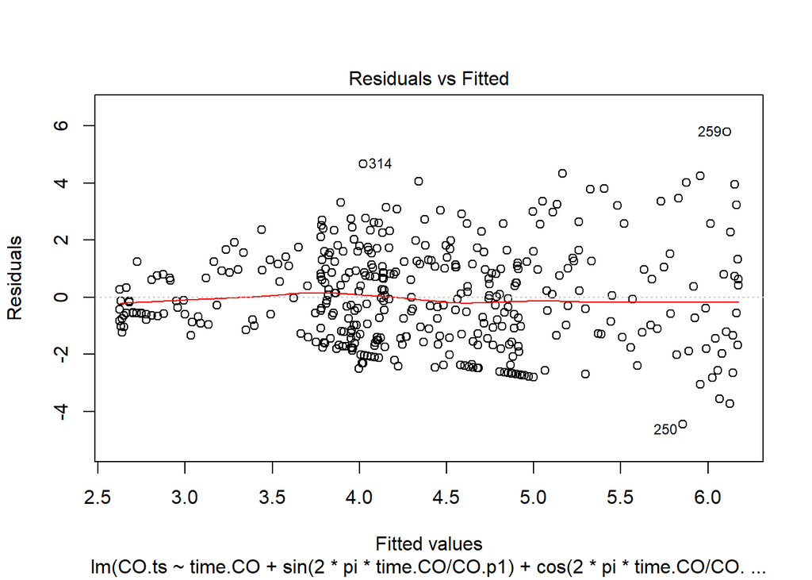

```r
plot(CO.seasonal5.trend, which = 1)
```

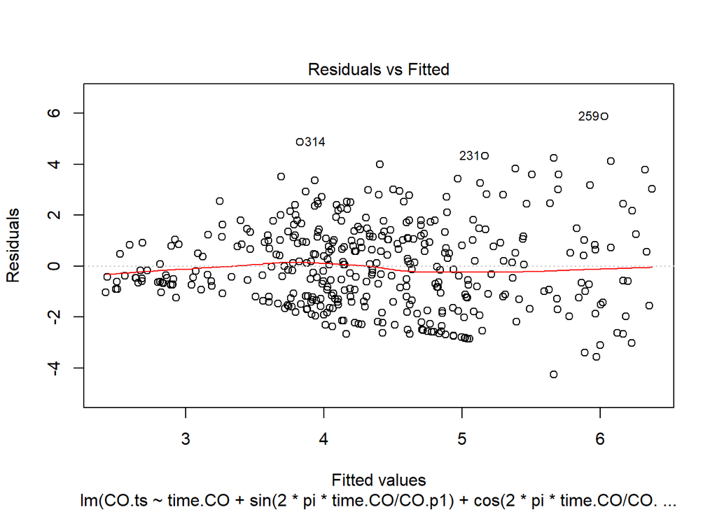

```r
plot(CO.seasonal6.trend, which = 1)
```

The mean of the residuals is approximately 0, but the variance is not constant for either model. There is less variance (less spread above and below the x-axis) on the left-hand side of the plot, and the variance increases to the right. The relationship evident in the plots indicates a lack of fit.

**QQ Plot**

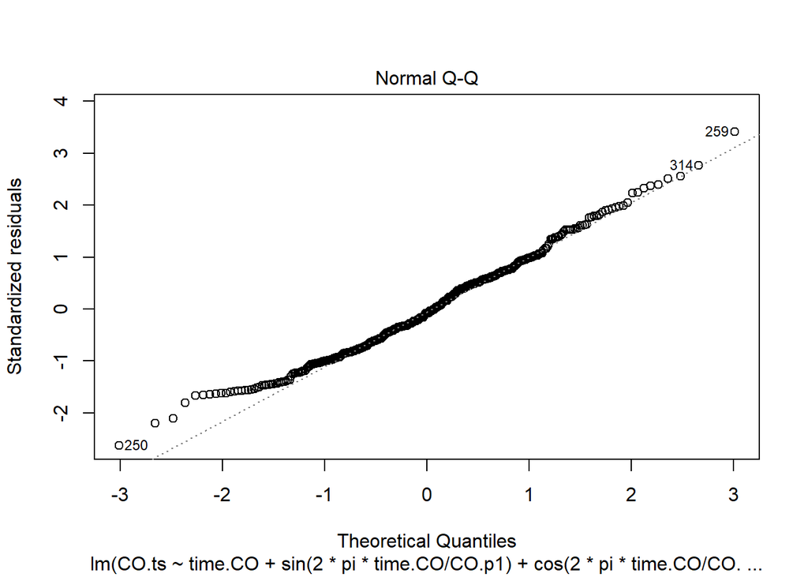

```r
plot(CO.seasonal5.trend, which = 2)
```

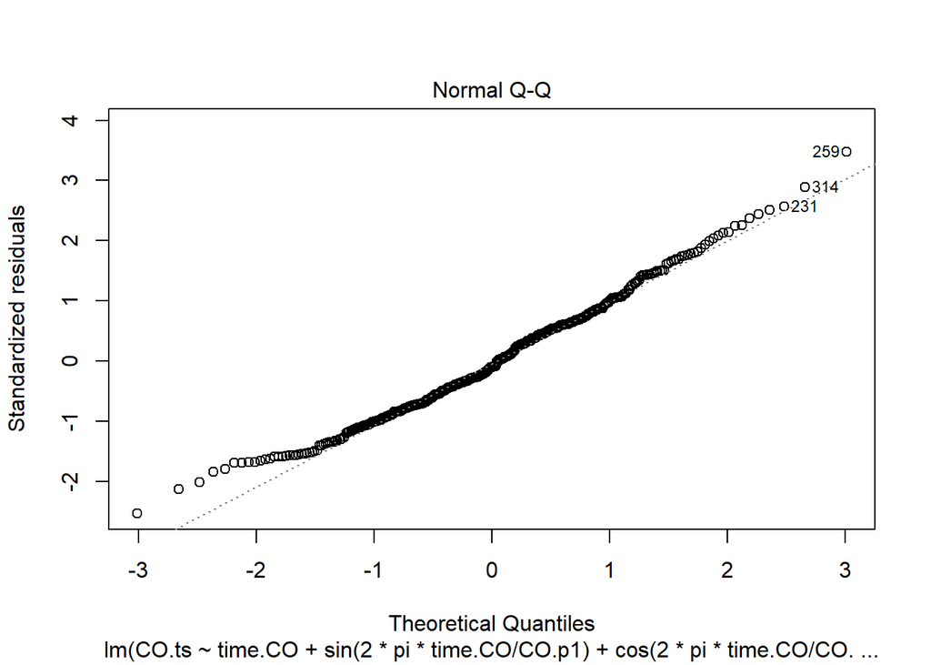

```r
plot(CO.seasonal6.trend, which = 2)
```

The residuals are approximately normal for both models, though the tails, and the lower tails especially, show some deviation from normality.

**Scale-Location Plot**

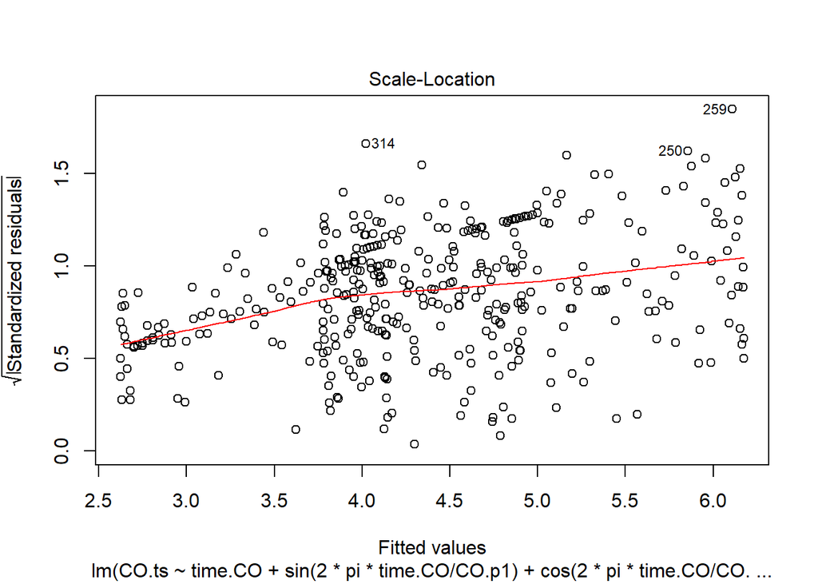

```r
plot(CO.seasonal5.trend, which = 3)
```

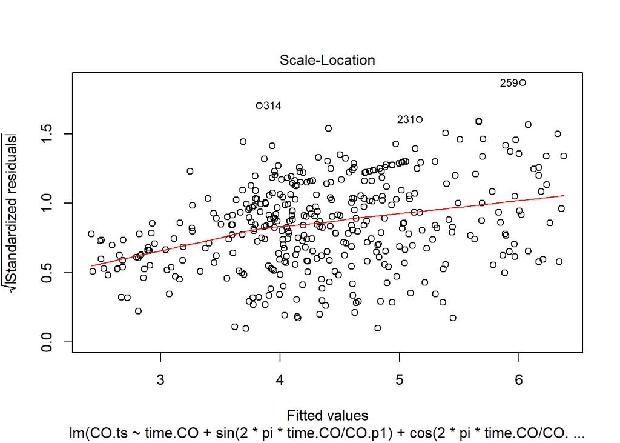

```r
plot(CO.seasonal6.trend, which = 3)
```

The mean is not centered at 0 and there may be a slight pattern to the scatter in both plots.

**Residuals vs. Leverage**

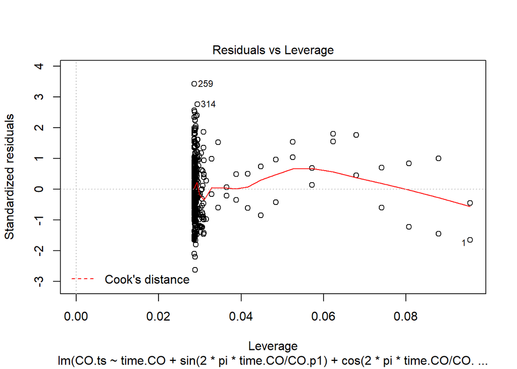

```r
plot(CO.seasonal5.trend, which = 5)
```

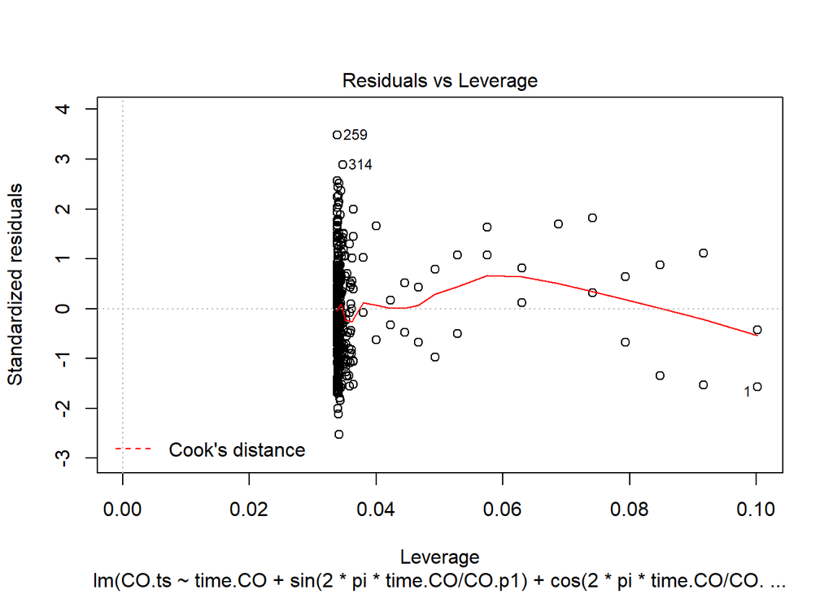

```r
plot(CO.seasonal6.trend, which = 5)
```

Neither plot has any points with Cook’s distances greater than 0.5.

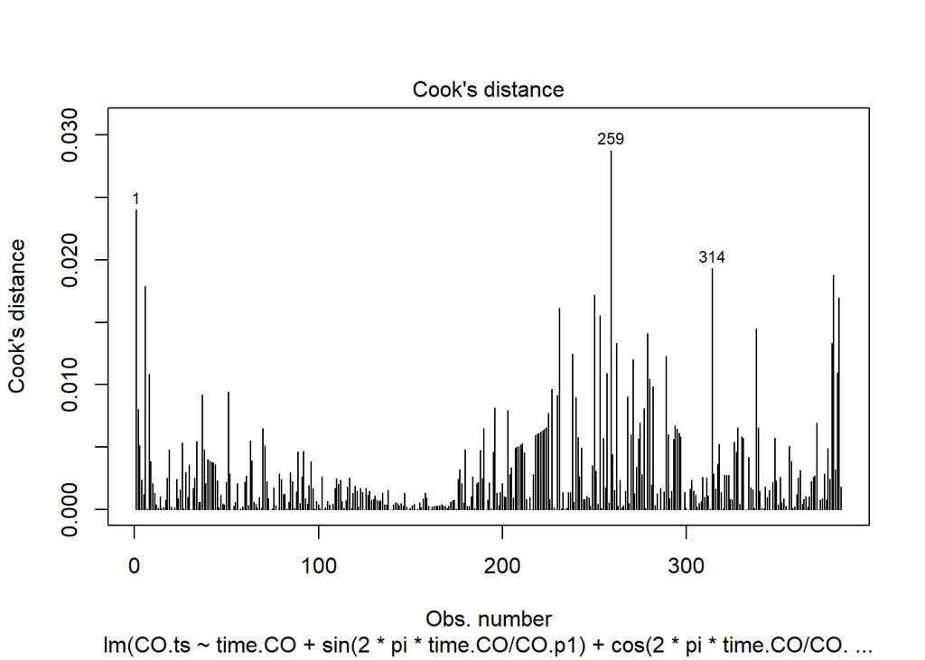

```r
# plot Cook's distances
plot(CO.seasonal5.trend,labels.id = NULL, which = 4)
```

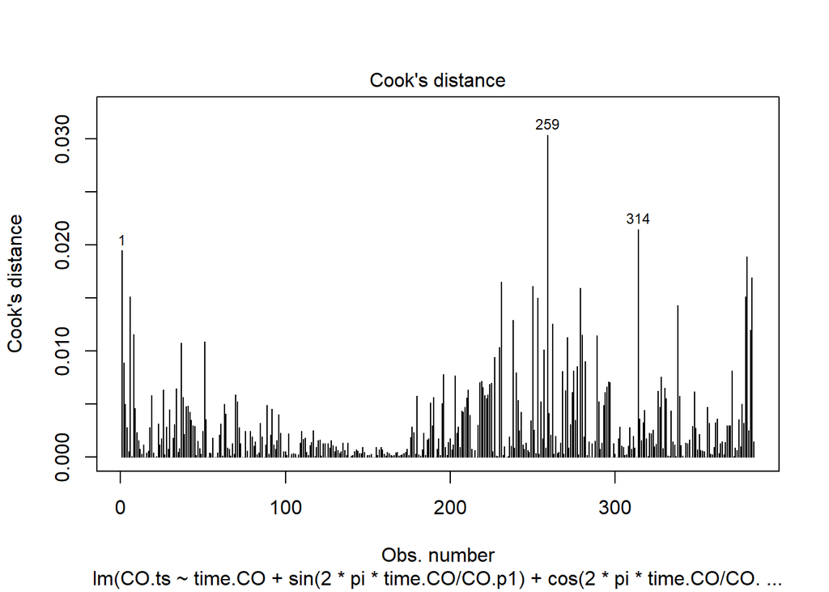

```r
plot(CO.seasonal6.trend,labels.id = NULL, which = 4)
```

These plots show that all of the points have small Cook’s distances for both models.

Both models perform very similarly in the diagnostics. We do not feel that either model needs a log or Box Cox transformation to improve the diagnostics.

### Choose Trend + Seasonal Model

```r
# create the combined model
CO.lm <- CO.seasonal5.trend
```

Since both models performed similarly in metrics and diagnostics, we have chosen to use the model with the trend and top five identified periods to explain seasonality. It was preferred from the partial F test, and we feel that it is better to choose the simpler model since the two models have such similar performance in metrics and diagnostics.